# Project 2 - Phase 3

Karolina Kwasiborska, Karol Dzitkowski, Marcel Szczęsny

2015-01-20

# Introdution

Copernicus Science Center is a museum which purpose is to promote and popularize science. Visitors can learn about the laws of nature by playing with interactive machines. In order to improve the visitor’s experience we analyzed their interaction with machines and found categories of visitors which are characterized by similar factors.

In the first phase we made exploratory analysis and characterized types of interactions with different machines. We tried to answer questions such as:

- What is the average time of interaction with a given machine?
- Is there a relation between the duraion of an interaction and variables like weekday or hour?

In the second phase we segmented visitors into groups. We tried to answer following questions:

- How to define the similarity measure between visitors? is the population homogenous or heterogonous. If heterogeneous then how many groups you can define?
- How to characterize different groups of visitors?
- Is there a pattern in stations that visitor tends to visit?

## Interactions with different machines

Characterize types of interactions with different machines (exploratory analysis). Try to answer following questions:

- What is the average (or distribution) time of interaction with a given machine
- Is there a difference in the time of interaction and weekday or hour?

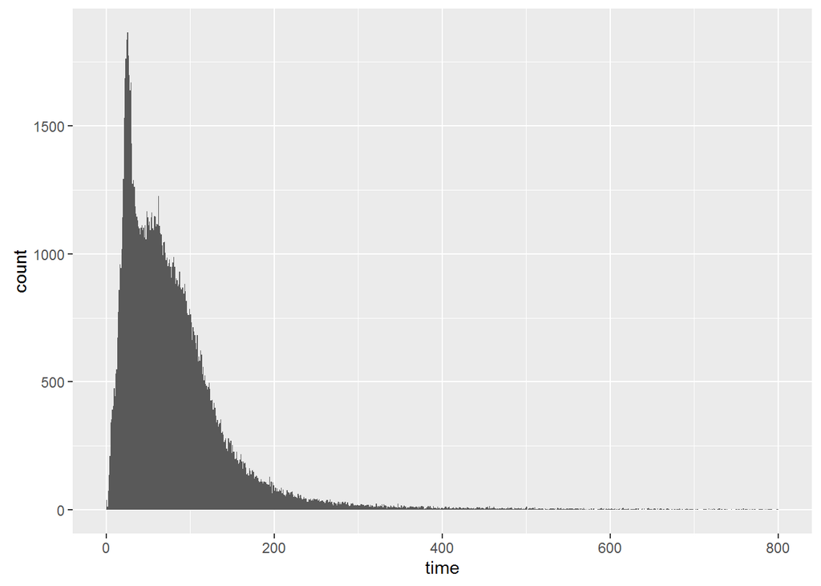

From the graph we can see that the most of interactions with machines took less then 200ms. There are a lot of outliers which can be eliminated using threshold “time < 400”. Moreover we will use median instead of mean to decrease impact of boundary values on results.

### What is the average time of interaction with a given machine

First we found average duration of visitors’ activities and the number of visitors in every station.

```
## Source: local data frame [9 x 3]
##
##   station avgTime visitorCount
##    (fctr)   (dbl)        (int)
## 1   cnk05      64        14757
## 2   cnk10      61        16551
## 3   cnk18      62        18663
## 4  cnk19a      28        27664
## 5   cnk20      94        14739
## 6   cnk38     143         7323
## 7   cnk56     103         9664
## 8   cnk61      64        12414
## 9   cnk66      95        14353
```

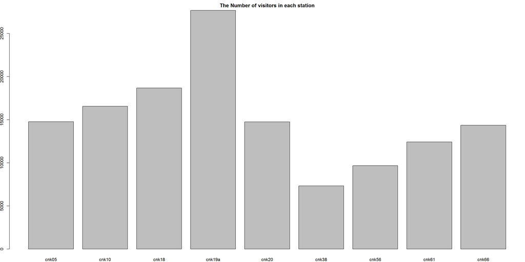

```
##    Min. 1st Qu.  Median    Mean 3rd Qu.    Max.
##    7323   12410   14740   15130   16550   27660
```

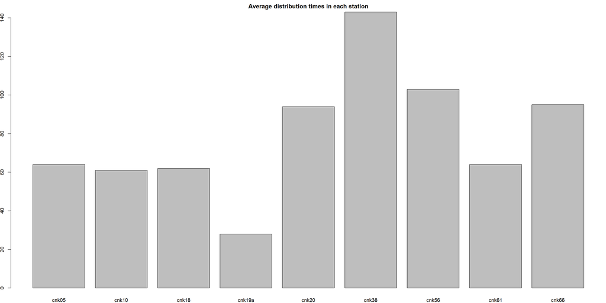

```
##    Min. 1st Qu.  Median    Mean 3rd Qu.    Max.
##   28.00   62.00   64.00   79.33   95.00  143.00
```

The station in which visitors spent definitely the most time is cnk38, therefore the least number of visitors played with it. With cnk19a visitors spent the least time per visit so the biggest amount of visitors had chance to play with it.

### Is there a relation between the duration of an interaction and variables like weekday or hour?

Then we check if there is a dependence between the duration of an interaction and weekday and hour.

#### Weekday

```
##   station Sunday Monday Tuesday Wednesday Thursday Friday Saturday
## 1   cnk05     70  144.5      61        62       60     63       69
## 2   cnk10     74  213.0      55        53       54     58       70
## 3   cnk18     66  179.0      60        59       60     60       65
## 4  cnk19a     29   52.5      28        28       28     28       29
## 5   cnk20     99  139.0      90        90       92     92       98
## 6   cnk38    149   96.0     140       139      138    140      152
## 7   cnk56    111     NA      98       100       98    103      110
## 8   cnk61     81   84.0      57        57       56     61       79
## 9   cnk66    100   50.0      90        91       91     94      101
```

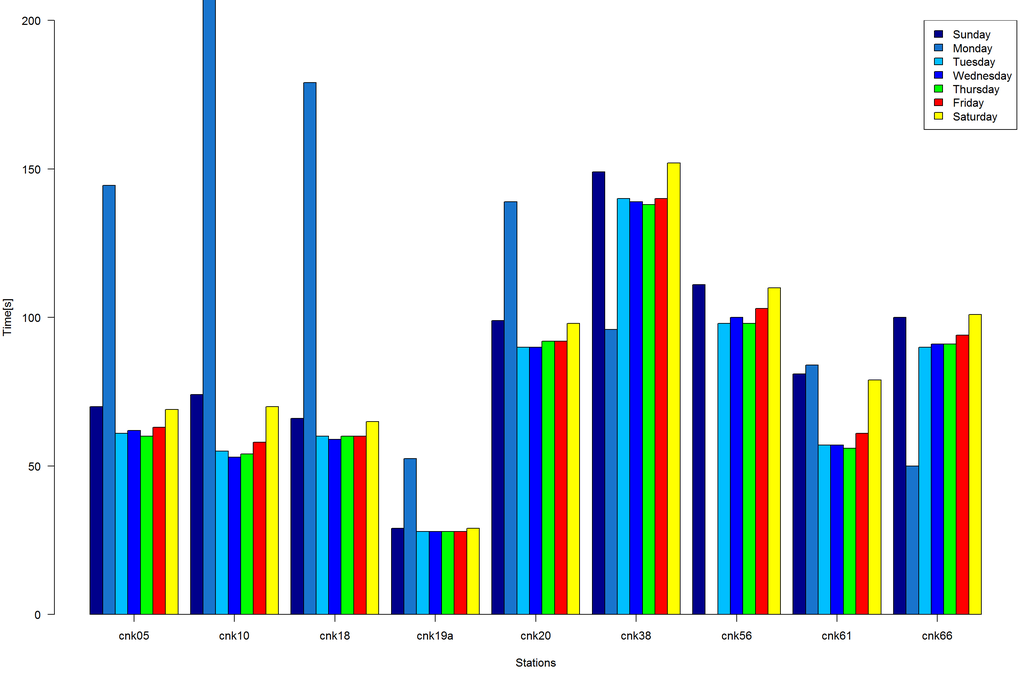

```
##   station Sunday Monday Tuesday Wednesday Thursday Friday Saturday
## 1   cnk05   2478      4    2326      2230     2393   2613     2713
## 2   cnk10   2593      3    2682      2587     2806   2950     2930
## 3   cnk18   3005      4    3021      2966     3100   3318     3249
## 4  cnk19a   4575      2    4338      4205     4566   4895     5083
## 5   cnk20   2391      3    2375      2341     2452   2603     2574
## 6   cnk38   1194      1    1185      1145     1229   1293     1276
## 7   cnk56   1570     NA    1590      1585     1564   1691     1664
## 8   cnk61   1852      1    2065      2029     2211   2198     2058
## 9   cnk66   2351      3    2325      2284     2402   2504     2484
```

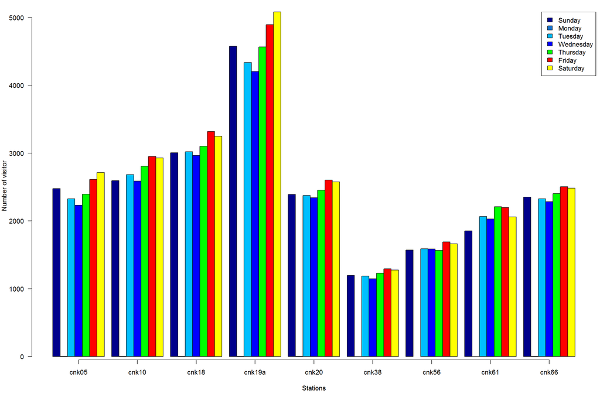

```
## Source: local data frame [7 x 3]
##
##     weekday avgTime visitorCount
##      (fctr)   (dbl)        (int)
## 1    Sunday      73        22009
## 2    Monday      84           21
## 3   Tuesday      62        21907
## 4 Wednesday      62        21372
## 5  Thursday      61        22723
## 6    Friday      64        24065
## 7  Saturday      72        24031
```

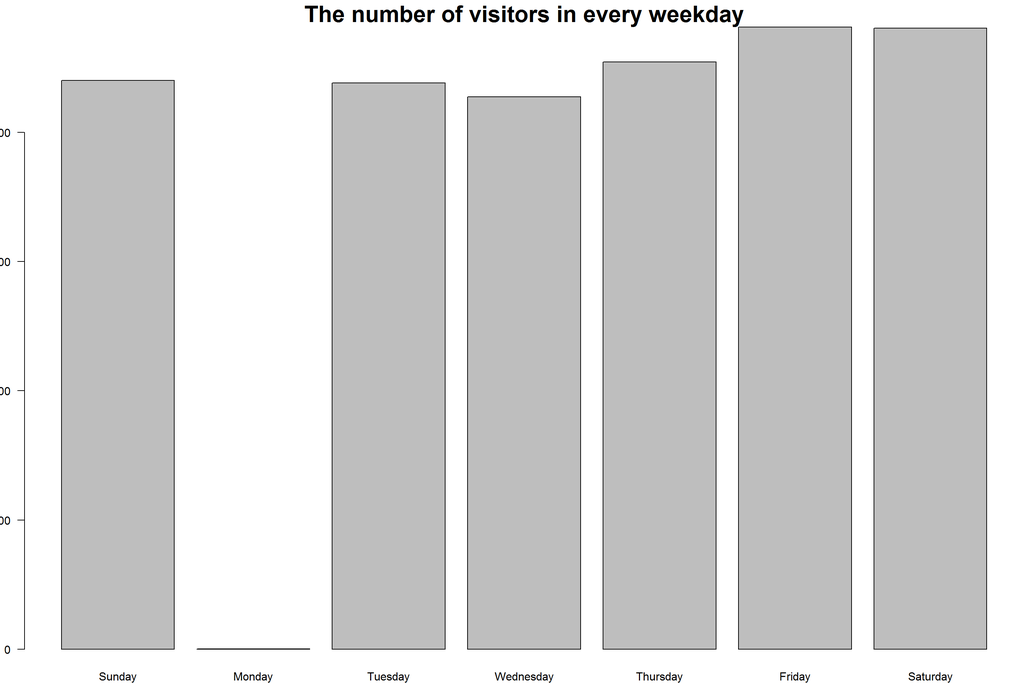

```
##    Min. 1st Qu.  Median    Mean 3rd Qu.    Max.
##      21   21640   22010   19450   23380   24060
```

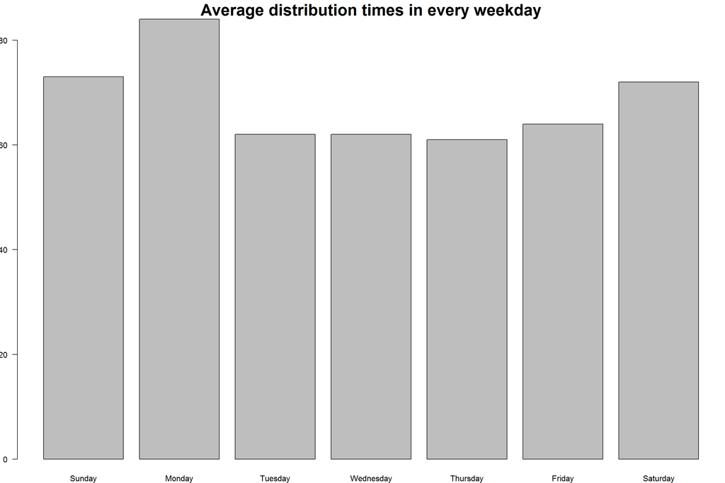

```
##    Min. 1st Qu.  Median    Mean 3rd Qu.    Max.
##   61.00   62.00   64.00   68.29   72.50   84.00
```

The average time spent in the stations and the number of visitors during different days of the week were quite similar. The only exception is Monday. Probably during Mondays stations are closed and the only activity with them is maintenance which takes more time than average visitor’s activity.

#### Hour

```
##   station  07    08    09  10    11  12  13  14  15  16    17  18    19
## 1   cnk05  NA    NA  61.0  61  63.0  65  66  65  66  64  63.0  60  59.0
## 2   cnk10  NA    NA  41.0  50  60.0  64  64  64  61  59  60.0  61  72.5
## 3   cnk18  NA    NA  54.0  57  60.0  62  62  63  62  61  62.0  67  42.0
## 4  cnk19a 541  30.0  32.0  33  29.0  27  28  28  27  27  30.0  32  53.0
## 5   cnk20  NA    NA  86.0  88  91.0  94  94  94  95  93  97.0  99  52.0
## 6   cnk38  NA    NA 119.0 127 141.0 141 147 146 145 143 140.5 146 181.0
## 7   cnk56  NA  36.0  69.5  81  92.5 105 108 114  99 106 110.0 102  75.5
## 8   cnk61  NA 349.5  38.0  48  55.0  64  67  68  69  64  67.0  83  42.5
## 9   cnk66  NA    NA  87.0  89  92.0  95  97  96  96  94  95.0 101  66.0
##      20    21
## 1 112.0    NA
## 2  38.0  51.0
## 3 229.0  80.5
## 4  45.0  69.0
## 5  90.0    NA
## 6    NA 156.5
## 7 163.0  33.0
## 8  47.0  84.0
## 9  79.5    NA
```

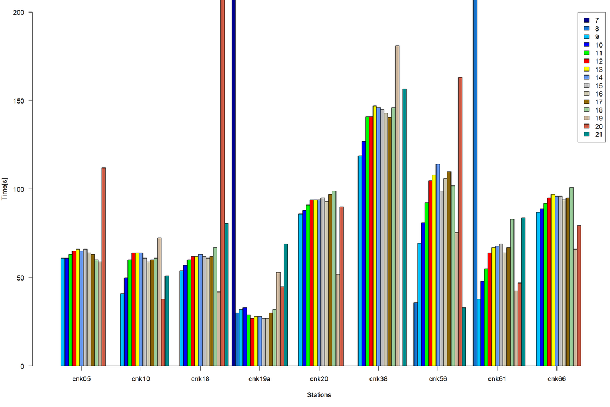

```
##   station 07 08  09   10   11   12   13   14   15   16   17  18 19 20 21
## 1   cnk05 NA NA 177  991 1838 2086 2057 2146 2128 1894 1132 304  3  1 NA
## 2   cnk10 NA NA 227 1118 2044 2353 2329 2337 2359 2158 1278 341  4  2  1
## 3   cnk18 NA NA 160 1073 2216 2650 2637 2583 2689 2514 1620 509  7  1  4
## 4  cnk19a  1  2 379 1600 3125 3866 3869 3711 4138 3888 2427 639 10  4  5
## 5   cnk20 NA NA 169  983 1817 2078 2059 2069 2043 1908 1232 379  1  1 NA
## 6   cnk38 NA NA  43  352  771 1078 1040 1059 1095 1019  646 215  3 NA  2
## 7   cnk56 NA  4  90  540 1014 1320 1303 1364 1393 1347  962 323  2  1  1
## 8   cnk61 NA  2  93  604 1371 1822 1731 1751 1867 1741 1129 293  4  1  5
## 9   cnk66 NA NA 183  941 1777 2015 1995 2017 2041 1874 1169 336  3  2 NA
```

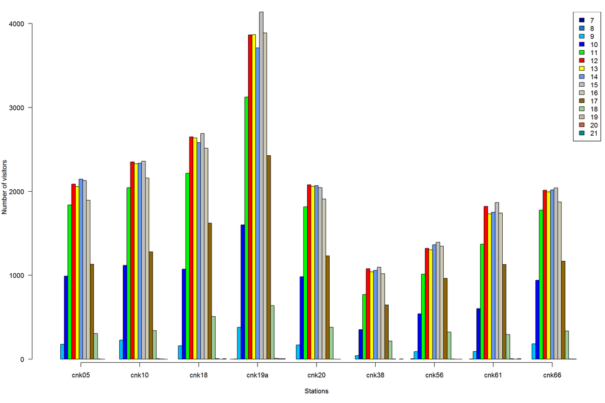

```
## Source: local data frame [15 x 3]
##
##     hour avgTime visitorCount
##    (chr)   (dbl)        (int)
## 1     07   541.0            1
## 2     08    38.5            8
## 3     09    52.0         1521
## 4     10    60.0         8202
## 5     11    63.0        15973
## 6     12    66.0        19268
## 7     13    67.0        19020
## 8     14    68.0        19037
## 9     15    65.0        19753
## 10    16    64.0        18343
## 11    17    67.0        11595
## 12    18    73.0         3339
## 13    19    54.0           37
## 14    20    56.0           13
## 15    21    76.5           18
```

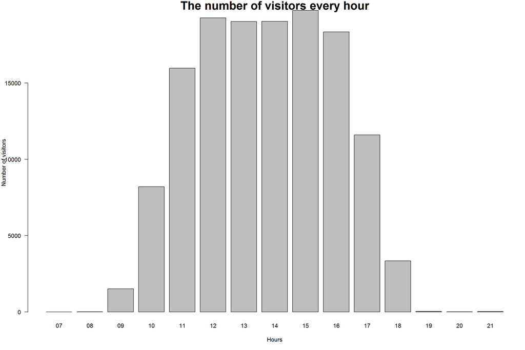

```
##    Min. 1st Qu.  Median    Mean 3rd Qu.    Max.
##     1.0    27.5  8202.0  9075.0 18680.0 19750.0
```

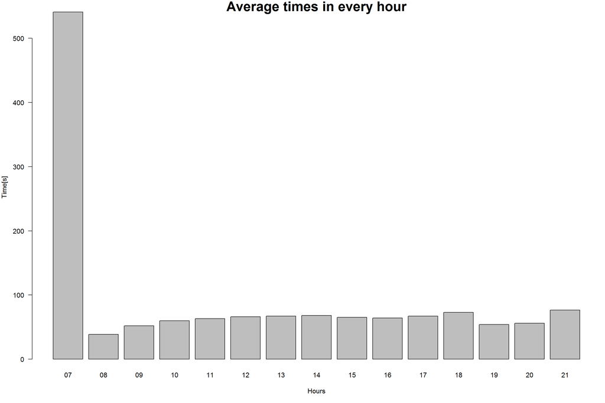

```
##    Min. 1st Qu.  Median    Mean 3rd Qu.    Max.
##   38.50   58.00   65.00   94.07   67.50  541.00
```

The greatest number of visitors came in the middle of the day (between 12 AM and 4 PM) In the evening (7PM - 9PM) and in the morning (7AM - 9AM) the activity of visitors was the smallest. Between 9PM and 7AM there was no interaction with stations at all.

In average the time spent in the stations was the highest at 7AM. In the morning spent time was the lowest. During the day differences weren’t very big.

#### Weekday and hour

```
##    Min. 1st Qu.  Median    Mean 3rd Qu.    Max.
##    4.00   55.00   70.00   79.35   96.00  661.00
```

```
##    Min. 1st Qu.  Median    Mean 3rd Qu.    Max.
##     1.0    81.0   237.0   236.7   346.0   785.0
```

```
##     weekday 07 08  09   10   11   12   13   14   15   16   17   18 19 20
## 1    Sunday NA NA  NA  352 1986 3025 3155 3219 3237 3153 2551 1322  9 NA
## 2    Monday NA NA   4    7    3   NA    1    4    1    1   NA   NA NA NA
## 3   Tuesday NA  3 216 1856 2879 3173 2996 3131 3367 2849 1429    8 NA NA
## 4 Wednesday NA  3 368 1713 2924 3273 3072 2914 3047 2741 1276   10  1 12
## 5  Thursday  1 NA 435 2002 2996 3279 3107 3223 3281 2953 1429   14  2  1
## 6    Friday NA  2 492 1852 3138 3437 3421 3244 3370 3217 1789  101  2 NA
## 7  Saturday NA NA   6  420 2047 3081 3268 3302 3450 3429 3121 1884 23 NA
##   21
## 1 NA
## 2 NA
## 3 NA
## 4 18
## 5 NA
## 6 NA
## 7 NA
```

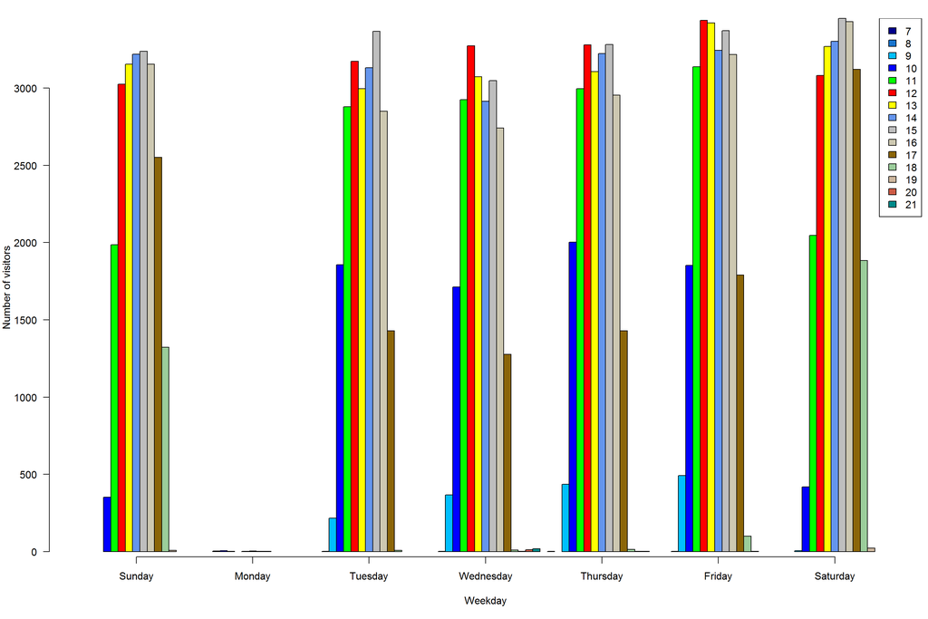

```
##     weekday  07   08    09 10  11 12  13   14 15 16   17   18    19 20
## 1    Sunday  NA   NA    NA 70  73 74  74 73.0 74 71 74.0 74.0  66.0 NA
## 2    Monday  NA   NA 151.0 50 244 NA 114 74.5 77 96   NA   NA    NA NA
## 3   Tuesday  NA 33.0  56.0 61  63 63  63 65.0 60 58 60.0 25.5    NA NA
## 4 Wednesday  NA 40.0  58.5 59  60 63  62 63.5 61 61 64.5 34.0 181.0 66
## 5  Thursday 541   NA  59.0 59  61 63  64 63.0 60 60 57.0 28.5  52.5 34
## 6    Friday  NA 29.5  42.0 57  59 64  67 69.0 66 63 64.0 81.0  54.0 NA
## 7  Saturday  NA   NA   5.0 72  68 71  74 73.0 72 70 72.0 72.0  52.0 NA
##     21
## 1   NA
## 2   NA
## 3   NA
## 4 76.5
## 5   NA
## 6   NA
## 7   NA
```

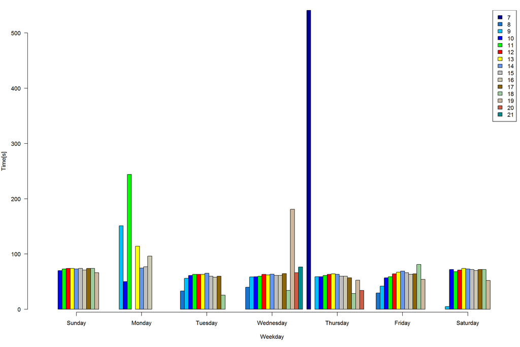

## Visitors segmentation

In the second phase try to segment visitors into separate categories / segments. Try to answer following questions:

- How to define the similarity measure between visitors?
- Is the population homogenous or heterogonous. If heterogeneous then how many groups you can derive/define?
- How to characterize different groups of visitors? Is there a pattern in stations that visitor tends to visit?

### Introducing new features

  Try to get data by visitor (not by visitor, station) and introduce new features that we tried to use in our clustering
  1. Time dependent features
     - total_time - total time spent by visitor on all stations
     - max_time - maximal time spent by visitor on one station
     - min_time - minimal time spent by visitor on one station
     - weekday - a day of a week
     - hour - an hour user started using stations
     - min_date - an hour with minutes as numeric type of entering first station by visitor
     - max_date - an hour with minutes as numeric type of leaving last station by visitor
  2. station dependent features
  - most_freq_station - a station with most interactions with that visitor
  - least_freq_station - a station with least interactions with that visitor
  - min_count - a minimal number of iteration with a station
  - max_count - a maximal number of iteration with a station
  - total_count - a total number of iterations with all stations made by the visitor

As a distance metric we will use deafault distance between vectors used by kmeans, of selected features from those above. To cluster our data in this part we will use kmeans algorithm.

### Use K-means on features: total_time, total_count

Firstly we tried to analyse visitors clustered by total_time and total_count features, splitting them to groups of visitors how play long and do many iterations and those to play shorter and do less interactions. In order to do that we cluster in 4 groups and analyze what stations people in every group mostly use.

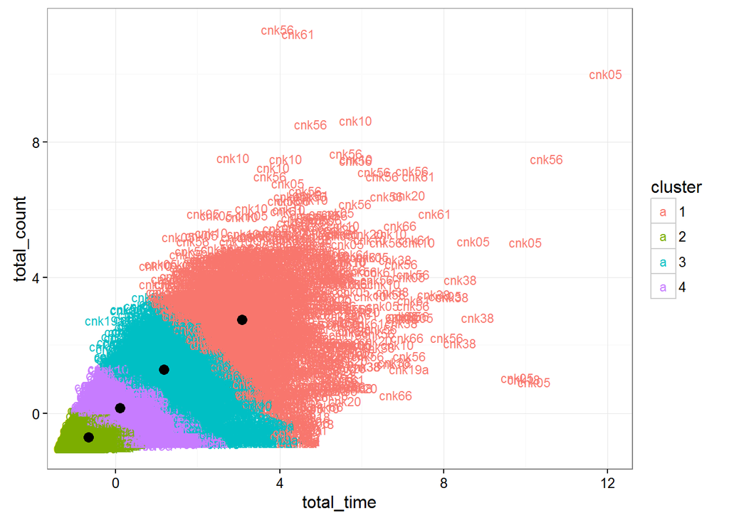

#### Most frequent station

```
##           1    2    3    4
## cnk05   432  367   36   20
## cnk10   119  440  735  240
## cnk18   235 2752 3090 5589
## cnk19a 9357 2894  722 1906
## cnk20  3008 2033 1741 1083
## cnk38   245   90  519 1788
## cnk56  1596  467 1664 3620
## cnk61  1707 1036  323 3093
## cnk66  2565 2215 1031 3332
```

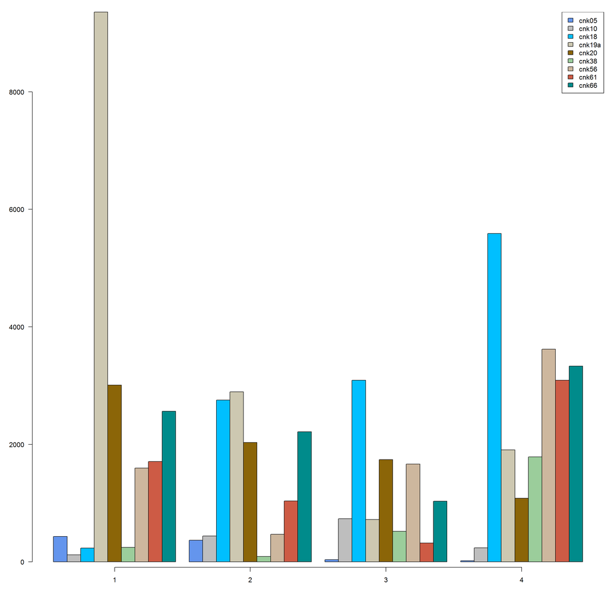

#### Least frequent station

We can find analogous situation if we analyse a station which is least used by clustered groups of visitors. We can see that distributions of least used station is much different in every group.

```
##           1     2    3    4
## cnk05   105  1989  408 1046
## cnk10   250  3248 1247 2680
## cnk18   444  3586 1454 2744
## cnk19a 1120 14273 3555 6611
## cnk20   153  1882  520 1085
## cnk38    45   681  205  932
## cnk56   145  1408  446 1192
## cnk61   261  2487  929 1650
## cnk66   101  1797  429  982
```

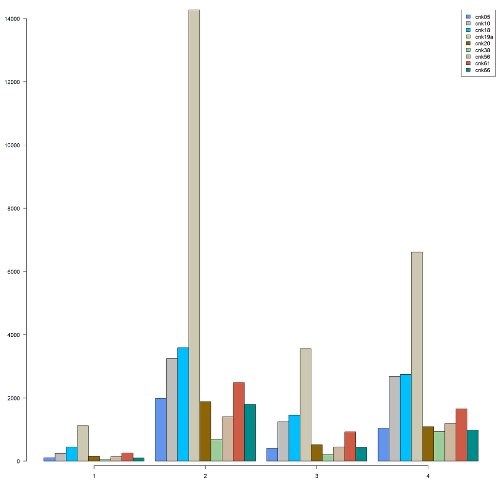

#### Hour

On the other hand all distributions based on hour visitors play are nearly normal (see normal distribution).

```r
hours = unique(c(as.character(kmFirstGroup$hour), as.character(kmSecondGroup$hour), as.character(kmThirdGroup$hour), as.character(kmFourthGroup$hour)))
hours = sort.int(hours)

table1 = table(as.character(kmFirstGroup$hour))
result <- rep(0, length(hours))
where <- match( names(table1), hours )
where = where[!is.na(where)]
result[ where ] <- table1
table1 = result

table2 = table(as.character(kmSecondGroup$hour))
result <- rep(0, length(hours))
where <- match( names(table2), hours )
where = where[!is.na(where)]
result[ where ] <- table2
table2 = result

table3 = table(as.character(kmThirdGroup$hour))
result <- rep(0, length(hours))
where <- match( names(table3),hours)
where = where[!is.na(where)]
result[ where ] <- table3
table3 = result

table4 = table(as.character(kmFourthGroup$hour))
result <- rep(0, length(hours))
where <- match( names(table4), hours)
where = where[!is.na(where)]
result[ where ] <- table4
table4 = result

table = c(table1, table2, table3, table4)


resultTab <- matrix(table, ncol=4, nrow = length(hours))
rownames(resultTab) <- hours
colnames(resultTab) <- c("1", "2", "3", "4")
resultTab
```

```
##      1    2    3    4
## 10 211 1647  591 1147
## 11 353 3669 1151 2177
## 12 385 4661 1298 2657
## 13 411 4323 1312 2675
## 14 350 4227 1362 2745
## 15 357 4820 1257 2766
## 16 281 4450 1111 2567
## 17 181 2534  760 1552
## 18  47  634  214  403
## 19   3   14    0    6
## 20   1    1    2    0
## 21   0    6    2    2
## 7    0    0    1    0
## 8    1    4    0    1
## 9   43  361  132  224
```

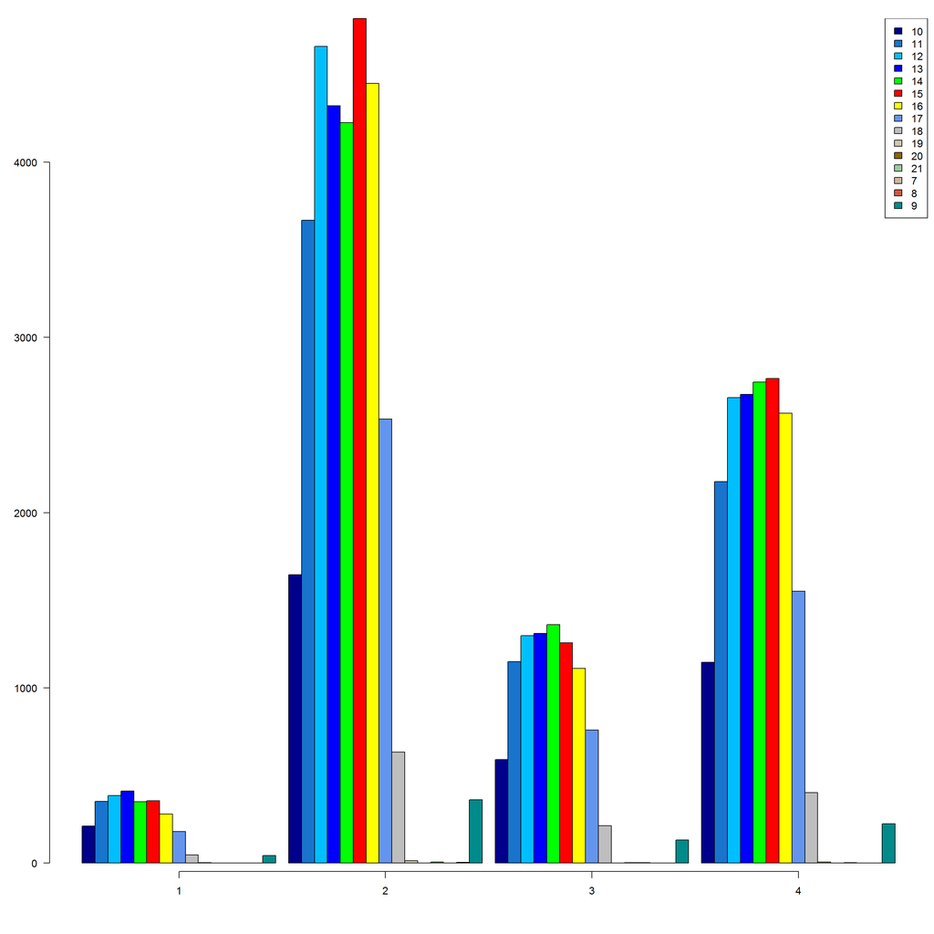

```r
par(mar = c(5, 4, 1.5, 0.5), ps = 12, cex  = 1, cex.main = 2, las = 1)
barplot(
  resultTab,
  beside      = TRUE,
  axes        = TRUE,
  axis.lty    = 1,
  col         = c("darkblue", "dodgerblue3", "deepskyblue1", "blue", "green", "red", "yellow", "cornflowerblue", "grey",  "cornsilk3", "darkgoldenrod4", "darkseagreen3", "bisque3", "coral3", "cyan4"),
  panel.first =  abline(
    h    =  seq.int(25, 100, 25),
    col  =  "grey",
    lty  =  2
  )
)

legend("topright",
       legend = hours,
       fill = c("darkblue", "dodgerblue3", "deepskyblue1", "blue", "green", "red", "yellow", "cornflowerblue", "grey",  "cornsilk3", "darkgoldenrod4", "darkseagreen3", "bisque3", "coral3", "cyan4"))
```

### Finding a pattern of stations visited by user

In order to find some pattern of stations visited by a user, we introduced new features and distance metric:

- first_station - a station that user begins with
- last_station - a station that user ends with
- station_path - a concatenated string of stations in order user visited them

Here as a distance metric we have to use some distance between strings, we use restricted Damerau-Levenshtein distance.

#### Clustering on station_path using hierarchical clustering with restricted Damerau-Levenshtein distance

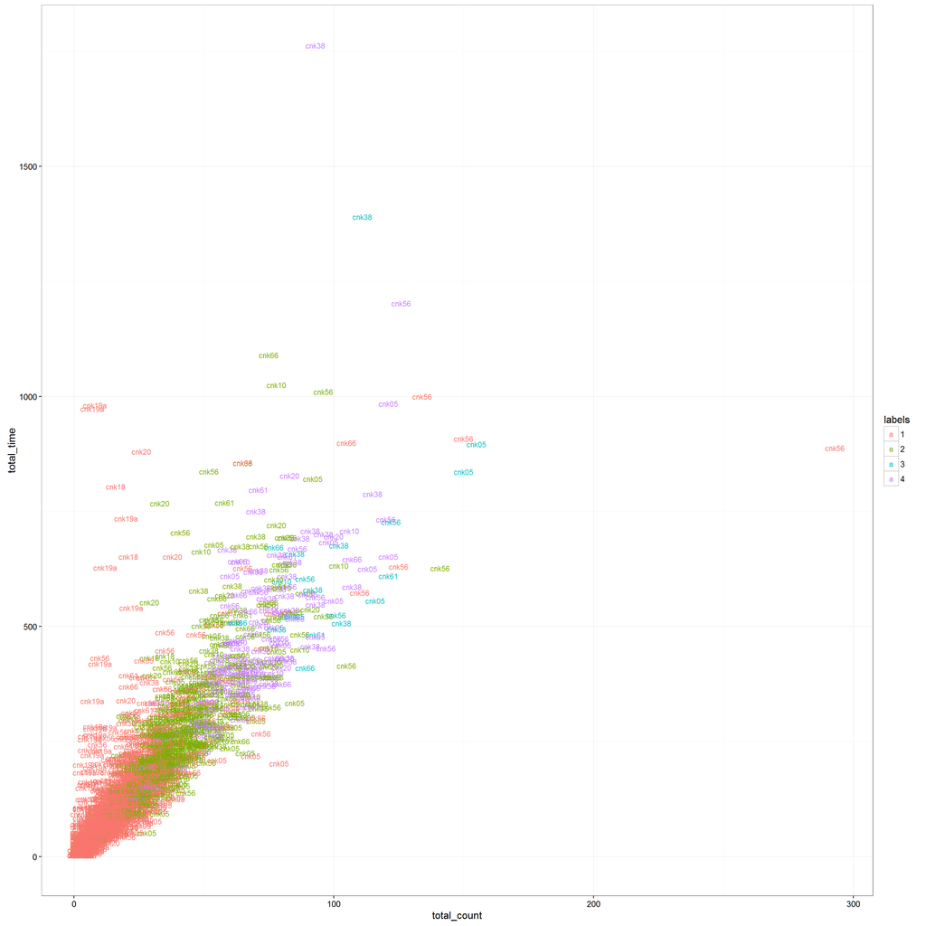

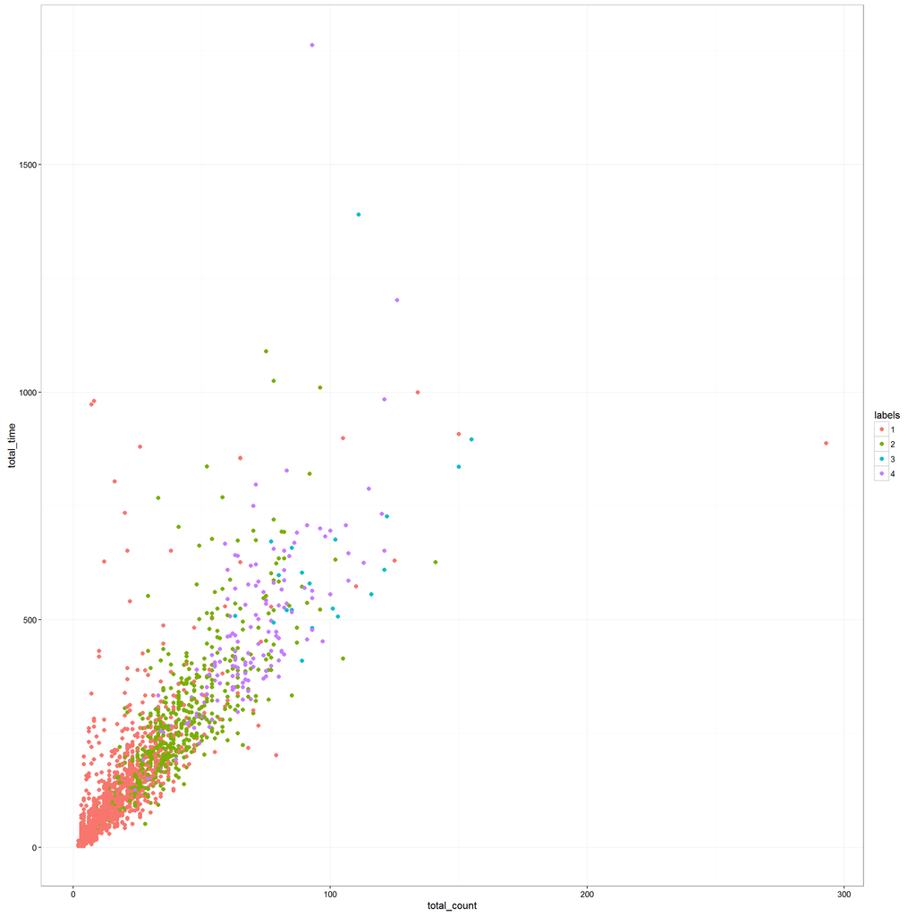

That way of clustering provides grouping visitors with similar behaviour together, for example with similar starting and ending station. However short playing visitors seem to nearly randomly choose their first station which is usually also their last one.

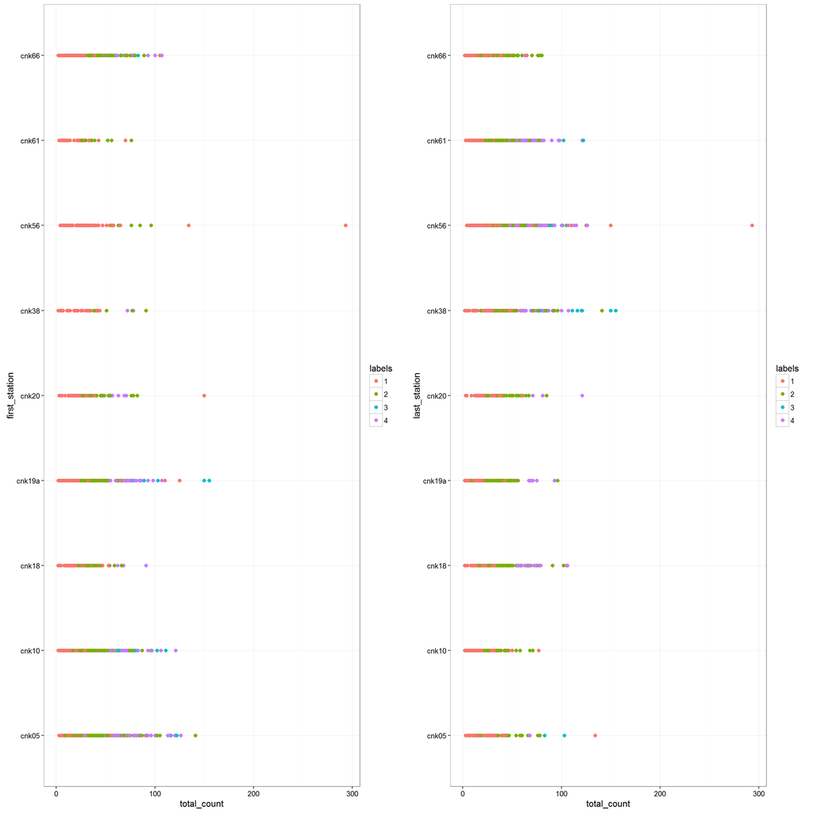

#### Analysis of clusters

As before we will try to compare distributions of most and least frequent stations in groups described by our clustering. We will also show total time distribution shown in every group (notice that we are not clustering on total_time this time).

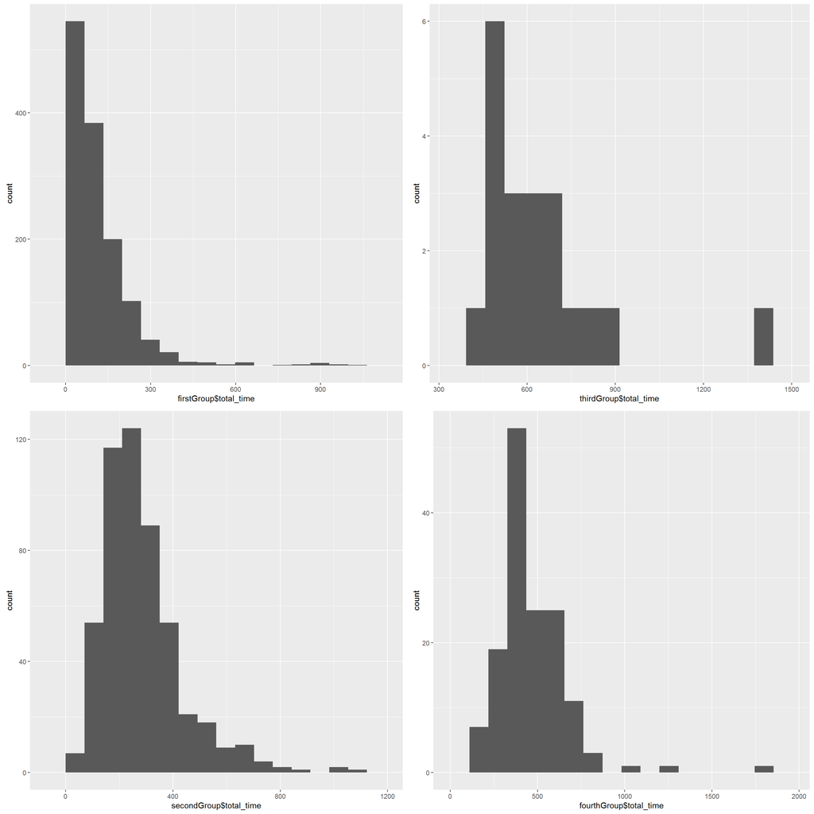

What we can see here that clustering divided our visitors to groups containing players with different characteristics of time spend on stations. As before we can see a group of players playing long (more than 500) and shortly (less than 500). We see that all people with very short total time are clustered to one group. This can mean that we clustered together people who used our stations “accidentaly” or “sporadically”. This is the kind of visitors which comes, play in one or to machines and go “home”. Next we will analize that data from most frequently used station point of view:

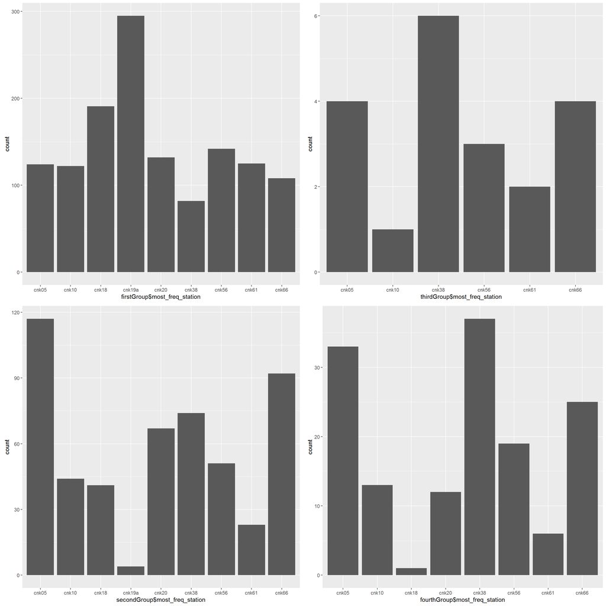

From the distributions of stations usage by groups of visitors we can see that a group of short players behaves much different than a group of long players which can be considered as common/constant visitors (we can consider them as experianced visitors). Short players use mostly cnk19a which is nearly never used by “long players”. However the more visitor play the more often he chooses cnk05 and cnk56 stations instead of cnk19a, cnk20 or cnk10.

```
## Source: local data frame [6 x 1]
##
##   station_path
##          (chr)
## 1  cnk61_cnk56
## 2        cnk18
## 3        cnk18
## 4        cnk66
## 5  cnk18_cnk56
## 6        cnk20
```

```
## Source: local data frame [6 x 1]
##
##              station_path
##                     (chr)
## 1 cnk66_cnk20_cnk05_cnk56
## 2 cnk05_cnk10_cnk66_cnk18
## 3       cnk10_cnk05_cnk20
## 4 cnk20_cnk66_cnk18_cnk56
## 5 cnk10_cnk20_cnk66_cnk38
## 6       cnk05_cnk10_cnk66
```

```
## Source: local data frame [6 x 1]
##
##                                 station_path
##                                        (chr)
## 1  cnk10_cnk05_cnk66_cnk20_cnk38_cnk56_cnk61
## 2  cnk10_cnk05_cnk66_cnk20_cnk18_cnk56_cnk38
## 3  cnk05_cnk10_cnk20_cnk66_cnk18_cnk61_cnk38
## 4 cnk05_cnk19a_cnk66_cnk20_cnk38_cnk56_cnk61
## 5 cnk05_cnk10_cnk20_cnk19a_cnk18_cnk38_cnk56
## 6 cnk10_cnk66_cnk19a_cnk05_cnk20_cnk18_cnk61
```

```
## Source: local data frame [6 x 1]
##
##                          station_path
##                                 (chr)
## 1       cnk20_cnk10_cnk05_cnk66_cnk18
## 2 cnk05_cnk10_cnk66_cnk20_cnk56_cnk38
## 3       cnk20_cnk61_cnk56_cnk66_cnk18
## 4 cnk10_cnk20_cnk66_cnk61_cnk56_cnk38
## 5 cnk05_cnk66_cnk20_cnk18_cnk61_cnk38
## 6       cnk05_cnk20_cnk18_cnk38_cnk61
```

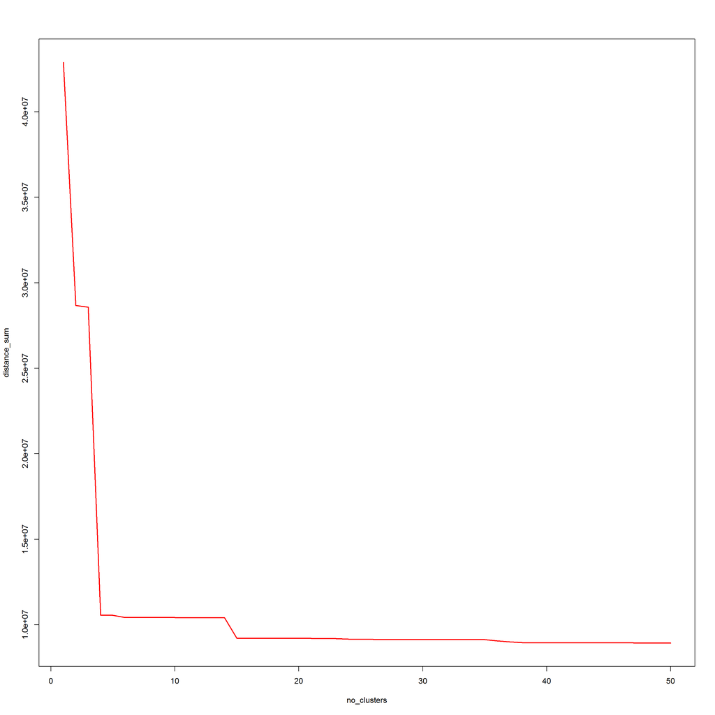

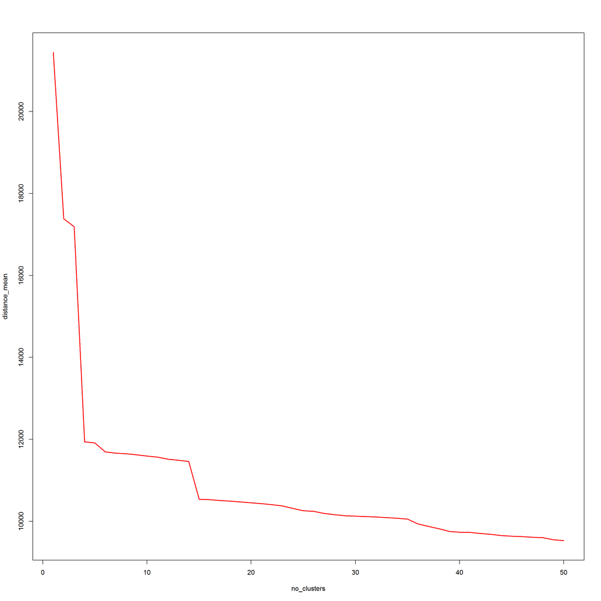

We can see that optimal number of clusters is 4-5 since there we have the most gain in mean distance reduction in clusters. For more than 5 clusters this “error” is changing very slowly. Also we can conclude that our data is heterogenous, since we have big drop in error at the beginning and then it flattens. If data were homogenous we would have uniform and steady slope.

# Summary

Interactions with different machines:

Moreover at different days times spent with machines where quite similar, therefore there is no need to plan any changes.

Visitors segmentation:

We distinguished following similarity measures:

1. Time dependent features
   - total_time - total time spent by visitor on all stations
   - max_time - maximal time spent by visitor on one station
   - min_time - minimal time spent by visitor on one station
   - weekday - a day of a week
   - hour - an hour user started using stations
   - min_date - an hour with minutes as numeric type of entering first station by visitor
   - max_date - an hour with minutes as numeric type of leaving last station by visitor
2. station dependent features
- most_freq_station - a station with most interactions with that visitor
- least_freq_station - a station with least interactions with that visitor
- min_count - a minimal number of iteration with a station
- max_count - a maximal number of iteration with a station
- total_count - a total number of iterations with all stations made by the visitor

The population is heterogeneous. Research carried out on the supplied data set showed that it is possible to distinguish four groups that show signs of similarities.

## Conclusions

After analysis we end up with some conclusions and we are able to provide some suggestions for management of the centre. Firstly, we found specific machines for which time of interaction with user is long (example: ‘cnk38’). Our idea is to increase number of such machines. Moreover, it will be a good concept to extend an exhibit with a machines, which concerns similar topic of science. Among the machines, which user interaction time is long, there are also machines which are rarely used. It means that visitors probably does not know how to use and enjoy playing with the machine. As a result they are discouraged. Our suggestion is to provide detailed instruction - user manual or ensure user’s guide for center’s employee. This will result in increased interest of such machines.

Segmentation of visitors allowed us to find 4 groups of visitors who have similar characteristics.

The first group are those who use small amount of machines, rather short and choose the stations randomly. Such people probably feel a little bit lost in the centre and do not know where to start. For those visitors the tours should be organized that will introduce to the most important matters of science. The guides should show the most interesting machines and encourage further exploration of science.

The second distinct group are visitors who spend a lot of time with machines and visit a lot of them. Taking into account that they often follow similar paths and watch similar machines, we can conclude that they visit the centre again and know which machines are most interesting. Moreover they are interested in science and eager to return to the centre. A good idea is to try to encourage them to watch the machines they visit rarely. To do this, you can arrange tours of the rarely visited machines. For this group of people guides can also organize special thematic meetings, during which visitors will gain more knowledge about topics of science that they are most interested in.

Middle-time players who (like short-time players) visits machines randomly can attend tours about basic topics of science to find some interesting subjects for them.